# Paritosh_Rai_Live_Session_Unit2_Assignment_Biv

Paritosh Rai

5/26/2019

# MSDS 6306: Doing Data Science

# Live session Unit 03 assignment

## Question 1:

### GitHub Cloning (20 points): Using Git, clone the following GitHub repository to your local machine: https://github.com/caesar0301/awesome-public-datasets.

**Clone the GitHub repository** * Use GUI clone to pull the file to local drive. * Datasets and titanic.csv file. * Unzipped the file and saved in same location Saved the file at following location on local drive in following folder: C:\6306 Doing Data Science3

## Question 2:

### 2. Data Summary (20 points): From this aforementioned cloned repo, please extract titanic.csv.zip. To be clear, this does not have to be done in Git or command line.

### a. In R, please read in titanic.csv via either read.table() or read.csv(), assigning it to df. This dataset follows the passengers aboard the Titanic, including their fees paid, rooms rented, and survivorship status.

### b. Output the respective count of females and males aboard the Titanic. Plot the frequency of females and males. Be sure to give an accurate title and label the axes.

### c. Please use one apply function (to review: swirl() modules 11, 12) to output the means of Age, Fare, and Survival. Make sure the output is a real number for all three means.

**Read the titanc file from local folder**

```r
# Read titanic.csv file  and assign it to df
#define the working directory
#this file share the passangers inforamtion including their fees paid, rooms rented, and survivorship status.

#setwd("C:/Paritosh/SMU/6306 Doing Data Science/Unit 3/Asst")

df <-read.csv(file="C:/Paritosh/SMU/6306 Doing Data Science/Unit 3/Asst/titanic.csv", header=TRUE)
df
```

[output not shown]

[output cut: 3553 more lines]

```r
#count and plat the male and female on baord

#count the number of male and female in titanic

sex_count<-table(df$Sex)
sex_count
```

```
##
## female   male
##    314    577
```

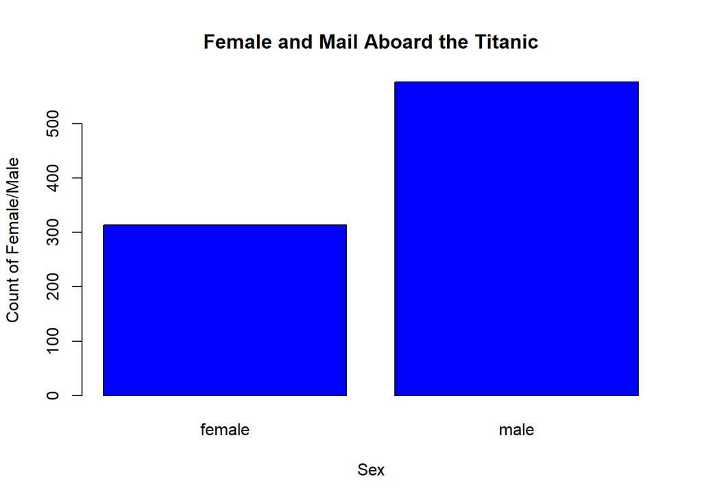

```r
# Count of female =314
# Count of male = 577
barplot(sex_count,main="Female and Mail Aboard the Titanic",xlab="Sex",ylab="Count of Female/Male", col = "blue")
```

```r
# x-axis is labled as Sex (male/female)
# y-axis is lanled as count of male/female

# Calculate means of Age, Fare, and Survival using apply function

#means of Age, Fare, and Survival
# col2: Survived, col6: Age, col10: Fare
# used na.rm to remove the NA from data to clean up

apply(df[,c(2,6,10)],2,mean,na.rm=TRUE)
```

```
##   Survived        Age       Fare
##  0.3838384 29.6991176 32.2042080
```

Survived Age Fare 0.3838384 29.6991176 32.2042080